# Cyfrowe modele wysokościowe

Krzysztof Dyba

```r
library("terra")
library("rgugik")
```

# Wstęp

## Cyfrowe modele wysokościowe

Cyfrowe modele wysokościowe to modele opisujące powierzchnię terenu. Powstają w wyniku obróbki zdjęć lotniczych, skanowania laserowego (LiDAR), pomiarów geodezyjnych czy interferometrii radarowej (InSAR). CMW są jednym z kluczowych zbiorów danych w systemach informacji geograficznej i stanowią podstawę wielu środowiskowych analiz przestrzennych. Ponadto są źródłem produktów pochodnych, takich jak cieniowanie, nachylenie czy szorstkość terenu.

CMW to ogólna nazwa grupy modeli o różnych cechach, uwzględniając:

- Numeryczny model terenu (*Digital Terrain Model*) – reprezentacja pozbawiona jakichkolwiek obiektów nad powierzchnią terenu, takich jak budynki czy drzewa.
- Numeryczny model pokrycia terenu (*Digital Surface Model*) – reprezentacja terenu wraz z jego pokryciem.

Cechy CMW:

- **Format** – można wyróżnić trzy główne struktury: GRID (regularna siatka punktów / komórek), TIN (nieregularna topologiczna sieć trójkątów) oraz linie konturowe (dane wektorowe). Obecnie najczęściej używanym formatem jest GRID.
- **Dokładność** – związana jest z pionowym błędem pomiaru.
- **Rozdzielczość przestrzenna** – związana jest z rozmiarem najmniejszego obiektu, który może zostać wykryty przez czujnik i jest określana przez rozmiar komórki obrazu (piksel). Im większa komórka, tym bardziej uogólniona forma terenu.

## Meteoryt Morasko

Naszym obszarem analiz jest rezerwat przyrody Meteoryt Morasko położony w północnej części Poznania. Został on utworzony w 1976 roku w celu ochrony obszaru kraterów uderzeniowych, które według badaczy powstały w wyniku upadku meteorytu Morasko około 5 tysięcy lat temu. Ponadto ochroną objęty jest las grądowy z rzadkimi gatunkami roślin i ptaków.

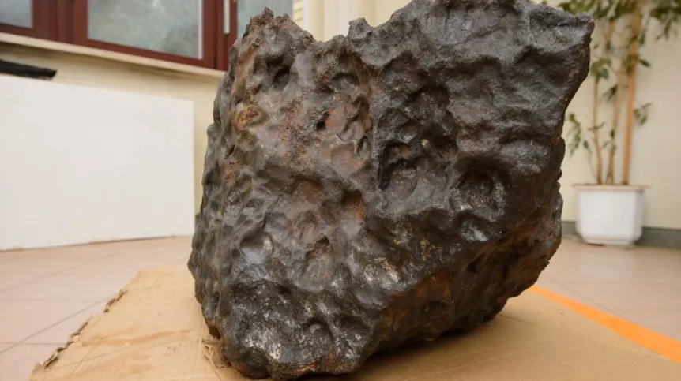

https://naukawpolsce.pl/aktualnosci/news%2C402631%2Csto-lat-temu-odkryto-pierwszy-fragment-meteorytu-morasko.html

*(Fot. PAP © 2012 / Jakub Kaczmarczyk)*

Więcej informacji znajdziesz tutaj:

- [Muzeum Ziemi WNGIG](https://muzeumziemi.amu.edu.pl/kolekcja-meteorytow/)
- [Ścieżka dydaktyczna](https://www.astro.amu.edu.pl/pl/popularyzacja/sciezka-morasko/)
- [Łowcy meteorytów, Discovery](https://www.youtube.com/watch?v=-i10oYQIkeI)

# Analiza

## Pozyskanie danych

Centroid (środek geometryczny) rezerwatu Morasko znajduje się na 16,895° długości geograficznej (X) i 52,489° szerokości geograficznej (Y). W celu wygenerowania tego punktu, możemy uprzednio stworzyć macierz, gdzie w wierszach znajdą się punkty (w naszym przypadku tylko jeden), a w kolumnach kolejno współrzędne X i Y. Następnie należy dokonać konwersji do obiektu wektorowego używając funkcji `vect()` i definiując układ współrzędnych.

```r
wspolrzedne = matrix(c(16.895, 52.489), ncol = 2)
centroid = vect(wspolrzedne, type = "points", crs = "EPSG:4326")
centroid
```

```
##  class       : SpatVector
##  geometry    : points
##  dimensions  : 1, 0  (geometries, attributes)
##  extent      : 16.895, 16.895, 52.489, 52.489  (xmin, xmax, ymin, ymax)
##  coord. ref. : lon/lat WGS 84 (EPSG:4326)
```

Dokonajmy również konwersji ze współrzędnych geograficznych na układ metryczny `EPSG:2180`.

```r
centroid = project(centroid, "EPSG:2180")
```

W kolejnym kroku stwórzmy przybliżoną strefę, która obejmie obszar rezerwatu.

```r
bufor = buffer(centroid, width = 400)
```

Stworzyliśmy bufor o szerokości 400 m, a teraz przygotujmy prostą wizualizację.

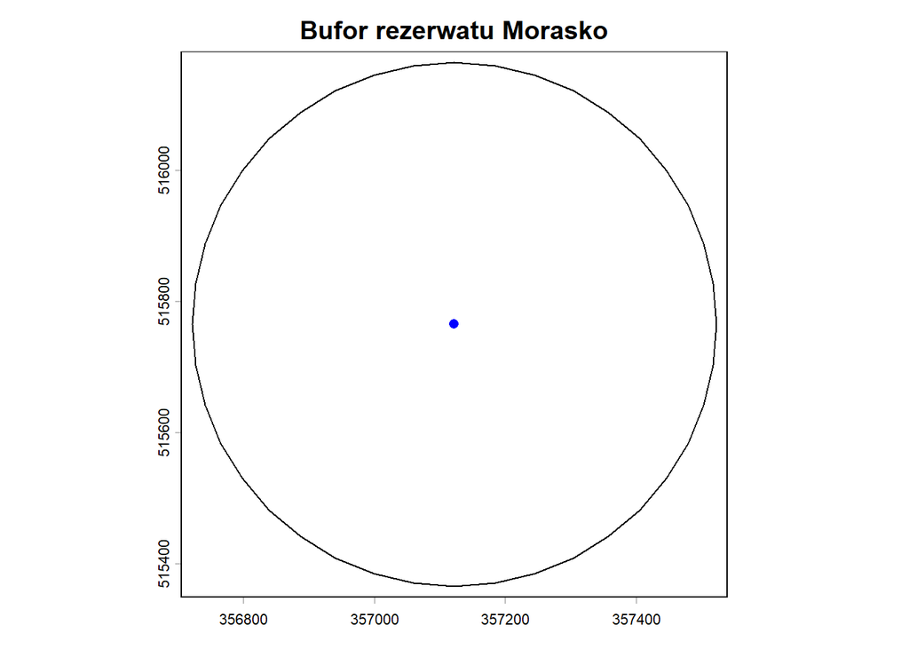

```r
plot(bufor, main = "Bufor rezerwatu Morasko")
plot(centroid, col = "blue", add = TRUE)
```

```r
dane = DEM_request(centroid)
```

Oczywiście pozyskane dane możemy sprawdzić wywołując obiekt `dane` lub przejrzeć je interaktywnie używając funkcji `View()`.

```r
# wyświetl 10 pierwszych wierszy i 6 pierwszych kolumn
dane[1:10, 1:6]
```

```
##                 sheetID year    product              format         source
## 1           6.179.11.14 2021        DSM ARC/INFO ASCII GRID Laser scanning
## 2           6.179.11.14 2021        DTM ARC/INFO ASCII GRID Laser scanning
## 3      N-33-130-D-b-1-1 2021        DTM ARC/INFO ASCII GRID   Aerial photo
## 4      N-33-130-D-b-1-1 2020        DTM ARC/INFO ASCII GRID   Aerial photo
## 5  N-33-130-D-b-1-1-4-1 2019 PointCloud                 LAS Laser scanning
## 6      N-33-130-D-b-1-1 2012        DSM      ASCII XYZ GRID Laser scanning
## 7      N-33-130-D-b-1-1 2012        DSM ARC/INFO ASCII GRID Laser scanning
## 8      N-33-130-D-b-1-1 2012        DTM      ASCII XYZ GRID Laser scanning
## 9  N-33-130-D-b-1-1-4-1 2012 PointCloud                 LAS Laser scanning
## 10     N-33-130-D-b-1-1 2012        DTM ARC/INFO ASCII GRID Laser scanning
##    resolution
## 1      0.50 m
## 2      0.50 m
## 3      5.00 m
## 4      5.00 m
## 5     12 p/m2
## 6      0.50 m
## 7      0.50 m
## 8      1.00 m
## 9     12 p/m2
## 10     1.00 m
```

Jak możemy zauważyć powyższe metadane opisują produkty o różnych formatach, aktualności, rozdzielczości oraz dokładności. Do naszej analizy potrzebujemy numerycznego modelu terenu (DTM) i numerycznego modelu pokrycia terenu (DSM) w formacie “ARC/INFO ASCII GRID”. Dokonajmy selekcji danych, tworząc dwie ramki danych i następnie łącząc je ze sobą przy pomocy funkcji `rbind()`.

```r
DTM_sel = dane[dane$format == "ARC/INFO ASCII GRID" &
               dane$product == "DTM" &
               dane$year == 2019, ]
DSM_sel = dane[dane$format == "ARC/INFO ASCII GRID" &
               dane$product == "DSM" &
               dane$year == 2019, ]

# połączenie powyższych ramek danych
dane_sel = rbind(DTM_sel, DSM_sel)
dane_sel[, 1:6]
```

```
##             sheetID year product              format         source resolution
## 18 N-33-130-D-b-1-1 2019     DTM ARC/INFO ASCII GRID Laser scanning     1.00 m
## 14 N-33-130-D-b-1-1 2019     DSM ARC/INFO ASCII GRID Laser scanning     0.50 m
```

Wykorzystajmy funkcję `tile_download()` do pobrania tych dwóch produktów.

```r
options(timeout = 600)
tile_download(dane_sel, outdir = "dane")
```

## Przetworzenie danych

Po pobraniu danych możemy je wczytać do sesji.

```r
DTM = rast("dane/73044_917579_N-33-130-D-b-1-1.asc")
DSM = rast("dane/73043_917495_N-33-130-D-b-1-1.asc")
```

Możemy również nadać warstwom odpowiednie nazwy oraz, co ważniejsze, przypisać im układy współrzędnych zdefiniowane w obiekcie `dane_sel` (atrybut `CRS`).

```r
# nadanie nazw warstwom
names(DTM) = "DTM"
names(DSM) = "DSM"

# ustawienie układu współrzędnych
crs(DTM) = crs(DSM) = "EPSG:2180"
```

Podczas pobierania prawdopodobnie zauważyłeś, że rastry różnią się czterokrotnie rozmiarem. Wynika to z różnicy ich rozdzielczości przestrzennej. W takiej sytuacji należy ujednolicić je do jednakowej rozdzielczości, aby móc je połączyć (nałożyć na siebie). Znacznie lepiej jest użyć niższej rozdzielczości niż ją sztucznie zwiększać, ponieważ nie możemy uzyskać więcej informacji, a przetwarzanie będzie szybsze. W tym celu użyjmy funkcji `resample()` i zapiszmy wynik na dysku określając ścieżkę w argumencie `filename`.

```r
DSM = resample(DSM, DTM, method = "near", filename = "dane/DSM_1.tif")
```

Teraz oba modele mają te same wymiary (liczbę wierszy i kolumn) oraz rozdzielczość przestrzenną. Możemy więc połączyć je w jeden obiekt o nazwie `DEM`.

```r
DEM = c(DTM, DSM)
nlyr(DEM)
```

```
## [1] 2
```

Używając funkcji `crop()` możemy ograniczyć zasięg przestrzenny (*bounding box*) do zasięgu przestrzennego rezerwatu Morasko. W celu wykluczenia z analizy wartości poza obszarem poligonu, należy zastosować funkcję `mask()`. Można tę czynność również wykonać w jednym kroku, używają funkcji `crop()` z argumentem `mask = TRUE`.

```r
DEM_crop = crop(DEM, bufor)
DEM_mask = mask(DEM_crop, bufor)

# alternatywnie
DEM = crop(DEM, bufor, mask = TRUE)
```

Zauważ, że domyślnie kolory zielony reprezentuje wysokie wartości, a kolor pomarańczowy niskie. Do wizualizacji danych topograficznych warto odwrócić paletę kolorów, tj. `terrain.colors(99, alpha = NULL)`.

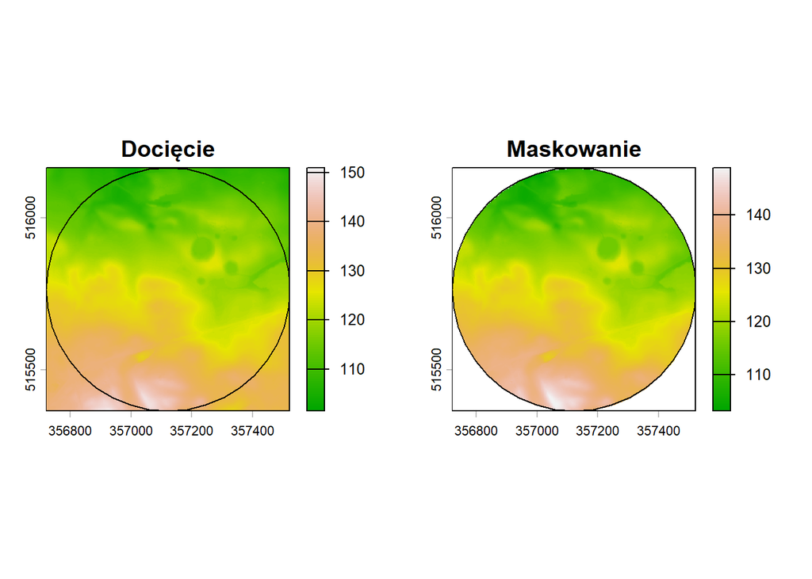

```r
par(mfrow = c(1, 2)) # wyświetl 2 rastry obok siebie
plot(DEM_crop$DTM, main = "Docięcie", col = terrain.colors(99, alpha = NULL))
plot(bufor, add = TRUE)
plot(DEM_mask$DTM, main = "Maskowanie", col = terrain.colors(99, alpha = NULL))
plot(bufor, add = TRUE)
```

W pierwszej ćwiartce okręgu widzimy pięć mniejszych okręgów. Są to kratery powstałe po uderzeniu meteorytu Morasko. Największy znaleziony fragment waży 272 kg i jest największym meteorytem znalezionym w Polsce. Kolekcję można zobaczyć w Muzeum Ziemi WNGIG w Poznaniu.

Obliczmy szerokość krateru na podstawie poprzecznego profilu terenu. Przyjmijmy, że punkt **A** ma współrzędne `(357280, 515980)`, a punkt **B** `(357122, 515760)`.

```r
punkty = matrix(c(357280, 515980,
                  357122, 515760),
                ncol = 2, byrow = TRUE)
linia = vect(punkty, type = "lines", crs = "EPSG:2180")
linia
```

```
##  class       : SpatVector
##  geometry    : lines
##  dimensions  : 1, 0  (geometries, attributes)
##  extent      : 357122, 357280, 515760, 515980  (xmin, xmax, ymin, ymax)
##  coord. ref. : ETRF2000-PL / CS92 (EPSG:2180)
```

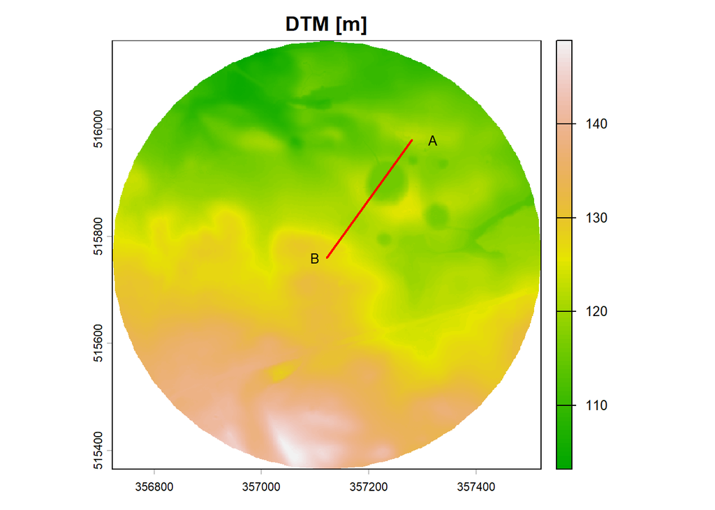

```r
plot(DEM$DTM, main = "DTM [m]", col = terrain.colors(99, alpha = NULL))
plot(linia, col = "red", lwd = 2, add = TRUE)
text("A", x = 357320, y = 515980, cex = 0.8)
text("B", x = 357100, y = 515760, cex = 0.8)
```

W kolejnym kroku pozyskamy wartości wysokości dla wyznaczonego profilu za pomocą funkcji `extract()`.

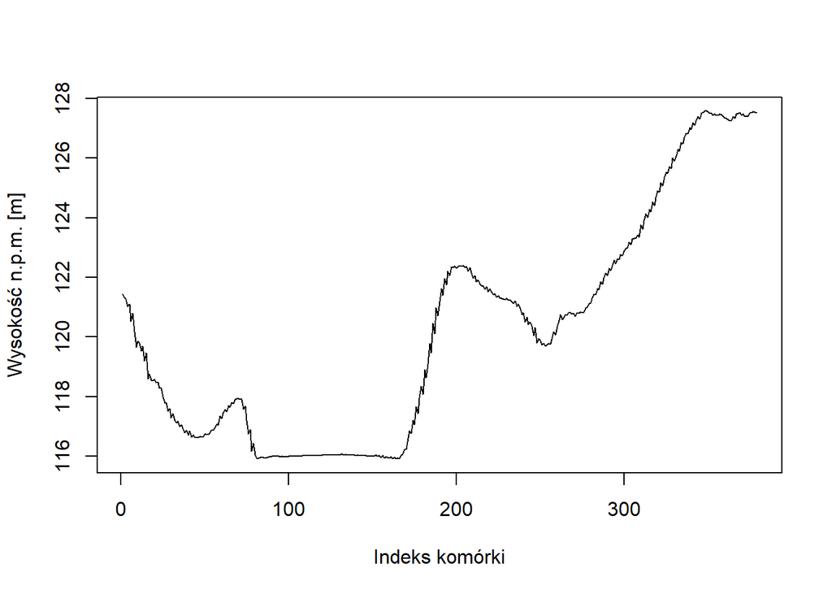

```r
profil = extract(DEM, linia)
profil = profil$DTM
plot(profil, type = "l", xlab = "Indeks komórki", ylab = "Wysokość n.p.m. [m]")
```

Na profilu widoczny jest szum wynikający z metody pozyskania danych. Można to wygładzić w prosty sposób wykorzystując funkcję `loess()`.

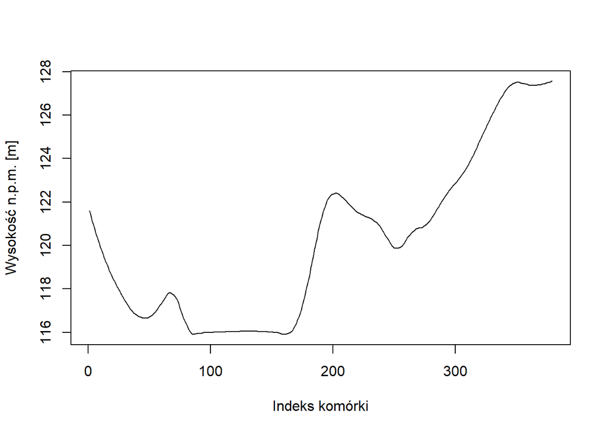

```r
profil = loess(profil ~ seq_along(profil), span = 0.1)
profil = profil$fitted
plot(profil, type = "l", xlab = "Indeks komórki", ylab = "Wysokość n.p.m. [m]")
```

Powyższe ryciny na osi X zawierają indeks komórki. Lepszym rozwiązaniem będzie przedstawienie tej osi jako odległości od punktu startowego (**A**). Aby to wykonać musimy obliczyć średnią odległość między komórkami, czyli podzielić długość linii przez liczbę komórek.

```r
odleglosc = perim(linia) / length(profil)
odleglosc
```

```
## [1] 0.7146646
```

Następnie stwórzmy wektor odległości kolejnych punktów od punktu startowego wykorzystując sumę skumulowaną `cumsum()`.

```r
odleglosc = cumsum(rep(odleglosc, length(profil)))
odleglosc[1:5] # odległość pierwszych 5 punktów
```

```
## [1] 0.7146646 1.4293293 2.1439939 2.8586585 3.5733232
```

Po tej operacji, możemy zaprezentować finalną wersję wykresu z zaznaczonym zasięgiem największego krateru uderzeniowego wynoszącą około 90 m.

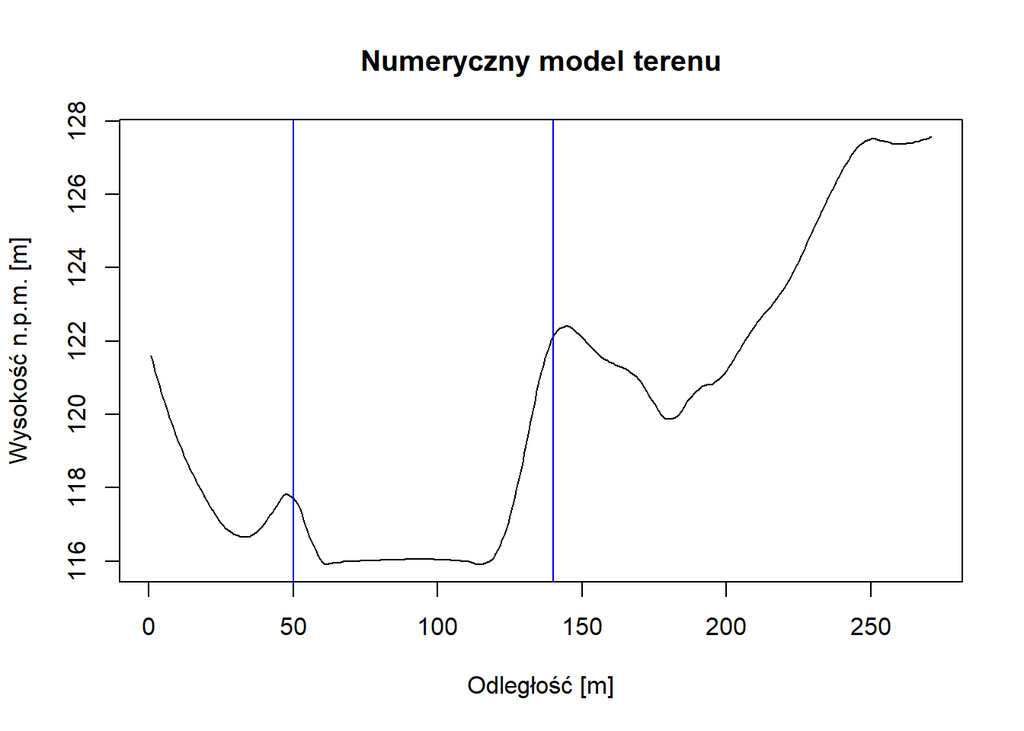

```r
plot(profil ~ odleglosc, type = "l", xlab = "Odległość [m]",
     ylab = "Wysokość n.p.m. [m]", main = "Numeryczny model terenu")
abline(v = c(50, 140), col = "blue")
```

W ostatnim kroku sprawdźmy wysokość obiektów (na tym obszarze są to drzewa). W tym celu należy odjąć NMT od NMPT. Różnica nazywana jest znormalizowanym NMPT, ponieważ przyjmuje wysokość terenu jako odniesienie.

```r
nDSM = DEM$DSM - DEM$DTM
nDSM
```

```
## class       : SpatRaster
## size        : 800, 800, 1  (nrow, ncol, nlyr)
## resolution  : 1, 1  (x, y)
## extent      : 356721.5, 357521.5, 515365.5, 516165.5  (xmin, xmax, ymin, ymax)
## coord. ref. : ETRF2000-PL / CS92 (EPSG:2180)
## source(s)   : memory
## varname     : 73044_917579_N-33-130-D-b-1-1
## name        :       DSM
## min value   : -4.159996
## max value   : 32.459999
```

```r
# nadpisz wartości poniżej 0
nDSM[nDSM < 0] = 0
```

Powyższą operację odejmowania można wykonać również używając funkcji `lapp()`.

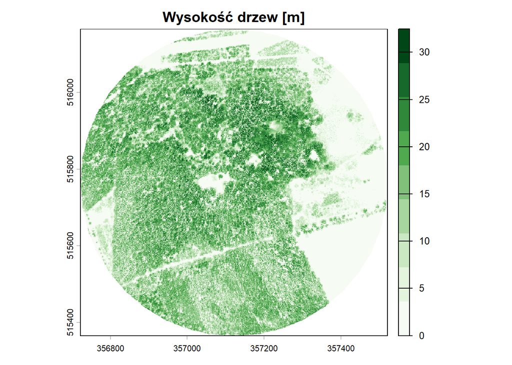

```r
plot(nDSM, main = "Wysokość drzew [m]",
     col = hcl.colors(9, palette = "Greens", rev = TRUE))
```

# Zadanie

**7.** Wykonaj analizę ukształtowania terenu wybranego obszaru, w której uwzględnisz:

- wizualizacje NMT i NMPT,
- statystyki opisowe wysokości terenu (wartość minimalna, maksymalna, średnia oraz odchylenie standardowe),
- profil wysokościowy,
- wizualizacje wysokości obiektów (znormalizowany NMPT).

Pamiętaj, że:

- Rastry powinny posiadać taką samą rozdzielczość przestrzenną oraz układ współrzędnych.
- Różnica między NMPT a NMT nie może być ujemna.